# 6306: Week 11 FLS

Matt Farrpw

11/1/2020

## Activity 1

Run this code and get a feel for what it is doing. Feel free to change it up and just learn by playing.

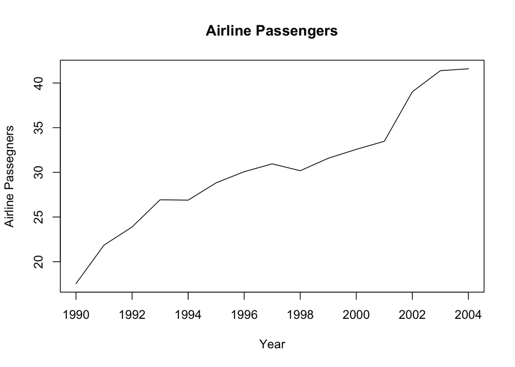

```r
# SES MODEL FOR AUS AIR
data(ausair)

# returns a ts object
air <- window(ausair, start = 1990, end = 2004)

# Always plot the data first!
plot(air, ylab = "Airline Passegners", xlab = "Year", main = "Airline Passengers")
```

```r
# fit 3 different simple exponential smoothing models ... how are they different?
# what does the h parameter do?
fit1 <- ses(air, initial = "simple", alpha = .2, h = 3)
fit2 <- ses(air, initial = "simple", alpha = .6, h = 3)
fit3 <- ses(air, h = 3) # defaults

# the forecast package has a nice accuracy funciton with various metrics just pass it the
# the model and the data! (This is the "training" data)
accuracy(fit1, ausair)
```

```
##                     ME      RMSE       MAE      MPE     MAPE     MASE
## Training set  5.864549  6.301705  5.864549 18.74164 18.74164 3.199632
## Test set     11.632265 11.751057 11.632265 24.77018 24.77018 6.346433
##                      ACF1 Theil's U
## Training set  0.405609699        NA
## Test set     -0.003569265  6.140567
```

```r
accuracy(fit2, ausair)
```

```
##                    ME     RMSE      MAE       MPE      MAPE     MASE
## Training set 2.576335 3.101549 2.582686  8.507273  8.528313 1.409084
## Test set     6.038897 6.264665 6.038897 12.797965 12.797965 3.294755
##                      ACF1 Theil's U
## Training set  0.206215181        NA
## Test set     -0.003569265  3.443693
```

```r
accuracy(fit3, ausair)
```

```
##                    ME     RMSE      MAE       MPE      MAPE      MASE
## Training set 1.602998 2.290962 1.710834  5.406487  5.766099 0.9334119
## Test set     5.182781 5.444168 5.182781 10.965507 10.965507 2.8276672
##                      ACF1 Theil's U
## Training set -0.085328673        NA
## Test set     -0.003569265  3.032778
```

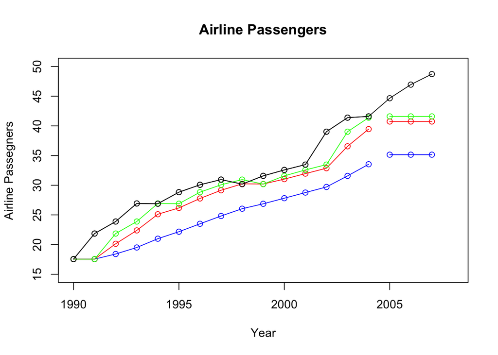

```r
# Reset the plot
plot(air, ylab = "Airline Passegners", xlab = "Year", type = "o", xlim = c(1990, 2008), ylim = c(15, 50), main = "Airline Passengers")

# Plot the estimated values from the models .. the "fitted" values are the training values.
lines(fitted(fit1), col = "blue", type = "o")
lines(fitted(fit2), col = "red", type = "o")
lines(fitted(fit3), col = "green", type = "o")

# the $mean values are the forecasts.
lines(fit1$mean, col = "blue", type = "o")
lines(fit2$mean, col = "red", type = "o")
lines(fit3$mean, col = "green", type = "o")

# These are the actual values! Compare visually with the forecasts!
air2008 <- window(ausair, start = 1990, end = 2007)
points(air2008, type = "o")
```

```r
# Compare the forecasts with the actual values with various fit metrics.
accuracy(fit1, air2008)
```

```
##                     ME      RMSE       MAE      MPE     MAPE     MASE
## Training set  5.864549  6.301705  5.864549 18.74164 18.74164 3.199632
## Test set     11.632265 11.751057 11.632265 24.77018 24.77018 6.346433
##                      ACF1 Theil's U
## Training set  0.405609699        NA
## Test set     -0.003569265  6.140567
```

```r
accuracy(fit2, air2008)
```

```
##                    ME     RMSE      MAE       MPE      MAPE     MASE
## Training set 2.576335 3.101549 2.582686  8.507273  8.528313 1.409084
## Test set     6.038897 6.264665 6.038897 12.797965 12.797965 3.294755
##                      ACF1 Theil's U
## Training set  0.206215181        NA
## Test set     -0.003569265  3.443693
```

```r
accuracy(fit3, air2008)
```

```
##                    ME     RMSE      MAE       MPE      MAPE      MASE
## Training set 1.602998 2.290962 1.710834  5.406487  5.766099 0.9334119
## Test set     5.182781 5.444168 5.182781 10.965507 10.965507 2.8276672
##                      ACF1 Theil's U
## Training set -0.085328673        NA
## Test set     -0.003569265  3.032778
```

## Activity 2: Holt Linear

Next, this is similar code with a different model (Holt with linear trend.) Again, run this code and get a feel for what it is doing. Feel free to change it up and just learn by playing.

```r
# 2 Holt's Linear Trend Model for AUS AIR
fit1h <- holt(air, alpha = .8, beta = .2, initial = "simple", h = 5)
fit2h <- holt(air, alpha = .8, beta = .2, initial = "simple", exponential = TRUE, h = 5)

# Check out estiamted values of the "training" data from the first holt model
fitted(fit1h)
```

```
## Time Series:
## Start = 1990
## End = 2004
## Frequency = 1
##  [1] 21.86010 22.03237 25.48462 27.54059 30.28813 30.26106 31.58122 32.59923
##  [9] 33.24224 32.26755 33.07776 33.95807 34.77708 40.05535 43.21586
```

```r
# Check out the forecast value (h of them)
fit1h$mean
```

```
## Time Series:
## Start = 2005
## End = 2009
## Frequency = 1
## [1] 43.75697 45.59352 47.43008 49.26663 51.10319
```

```r
# Reset the Plot!
plot(air, ylab = "Airline Passegners", xlab = "Year", type = "o", xlim = c(1990, 2009), ylim = c(15, 60))

# Plot each models estimated values of the training data (Do these one by one to see the differences)
lines(fitted(fit1h), col = "blue", type = "o")
lines(fitted(fit2h), col = "red", type = "o")

# Plot each models forecasts (Do these one by one to see the differences)
lines(fit1h$mean, col = "blue", type = "o")
lines(fit2h$mean, col = "red", type = "o")

# Fit another model ... damped!
fit3h <- holt(air, alpha = .8, beta = .2, damped = TRUE, initial = "optimal", h = 5)

# Plot the fitted value (estimated from triaining data)
lines(fitted(fit3h), col = "darkgreen", type = "o")

# Plot the forecasts
lines(fit3h$mean, col = "darkgreen", type = "o")

# Fit another model ... what is the difference?
fit4h <- holt(air, alpha = .8, beta = .2, damped = TRUE, initial = "optimal", exponential = TRUE, h = 5)

# Plot the fitted value (estimated from triaining data)
lines(fitted(fit4h), col = "cyan", type = "o")

# Plot the forecasts
lines(fit4h$mean, col = "cyan", type = "o")

# with implicit Test set... it figures out by the time which are training and which are test.
accuracy(fit1h, ausair)
```

```
##                      ME     RMSE      MAE       MPE     MAPE      MASE
## Training set -1.0292272 2.202869 1.772637 -4.485612 6.364749 0.9671310
## Test set      0.9405879 1.444776 1.371076  1.947628 2.808140 0.7480438
##                    ACF1 Theil's U
## Training set  0.2088940        NA
## Test set     -0.3313068 0.7212626
```

```r
accuracy(fit2h, ausair)
```

```
##                     ME     RMSE      MAE       MPE     MAPE     MASE      ACF1
## Training set -2.010092 2.908422 2.565680 -7.724285 9.137707 1.399806 0.3109081
## Test set     -1.836519 2.883708 1.859959 -3.672580 3.725068 1.014773 0.1029680
##              Theil's U
## Training set        NA
## Test set      1.403487
```

```r
accuracy(fit3h, ausair)
```

```
##                     ME     RMSE      MAE       MPE     MAPE     MASE      ACF1
## Training set 0.3317307 1.653933 1.084962 0.7156323 3.371681 0.591943 0.1675855
## Test set     3.8715783 4.131618 3.871578 7.8802382 7.880238 2.112290 0.2453622
##              Theil's U
## Training set        NA
## Test set      2.086233
```

```r
# with explicit Test set ... (same output)
airTest <- window(ausair, start = 2005)
accuracy(fit1h, airTest)
```

```
##                      ME     RMSE      MAE       MPE     MAPE      MASE
## Training set -1.0292272 2.202869 1.772637 -4.485612 6.364749 0.9671310
## Test set      0.9405879 1.444776 1.371076  1.947628 2.808140 0.7480438
##                    ACF1 Theil's U
## Training set  0.2088940        NA
## Test set     -0.3313068 0.7212626
```

```r
accuracy(fit2h, airTest)
```

```
##                     ME     RMSE      MAE       MPE     MAPE     MASE      ACF1
## Training set -2.010092 2.908422 2.565680 -7.724285 9.137707 1.399806 0.3109081
## Test set     -1.836519 2.883708 1.859959 -3.672580 3.725068 1.014773 0.1029680
##              Theil's U
## Training set        NA
## Test set      1.403487
```

```r
accuracy(fit3h, airTest)
```

```
##                     ME     RMSE      MAE       MPE     MAPE     MASE      ACF1
## Training set 0.3317307 1.653933 1.084962 0.7156323 3.371681 0.591943 0.1675855
## Test set     3.8715783 4.131618 3.871578 7.8802382 7.880238 2.112290 0.2453622
##              Theil's U
## Training set        NA
## Test set      2.086233
```

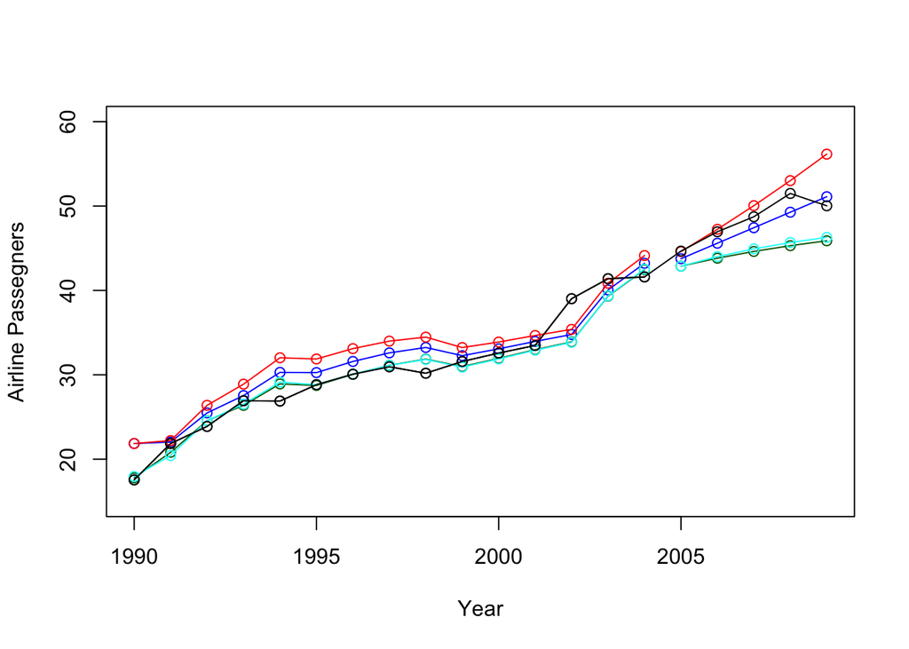

```r
# Add the actual values to visually compare forecasts to actual values
air2008 <- window(ausair, start = 1990, end = 2009)
points(air2008, type = "o")
```

## Activity 3: Holt Seasonal

We are changing the data this time. Still just learn by playing with the code and looking closely at the input arguments and the output. Also, record any questions that pop up while you are playing. We can discuss them in live session.

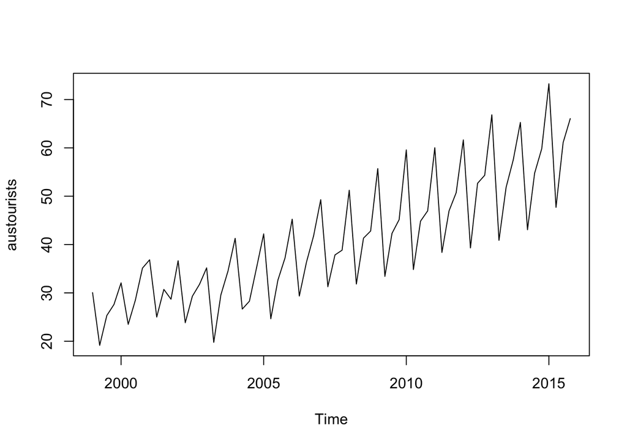

```r
# Load the data
data("austourists")

# Read about the data set!
# ?austourists

# Always plot the data first!
plot(austourists)
```

```r
# returns a ts object.
aust <- window(austourists, start = 1999, end = 2004)

# fit an additive and multiplicative model
fit1s <- hw(aust, seasonal = "additive", h = 40)
fit2s <- hw(aust, seasonal = "multiplicative", h = 40)

# Plot the original data
plot(aust, ylab = "Australian Tourists", xlab = "Year", type = "o", xlim = c(1999, 2014), ylim = c(15, 60))

# add the fitted values from the model (of the training data)
lines(fitted(fit1s), col = "blue", type = "o")
lines(fitted(fit2s), col = "red", type = "o")

# Now add the forecasts (add these one at a time)
lines(fit1s$mean, col = "blue", type = "o")
lines(fit2s$mean, col = "red", type = "o")

# Compare the accuracy
accuracy(fit1s, austourists)
```

```
##                      ME     RMSE      MAE        MPE      MAPE      MASE
## Training set -0.4377946 2.266717 1.882623  -1.842903  6.492401 0.6090876
## Test set     -5.8512519 6.944442 5.938676 -14.826323 14.975416 1.9213477
##                     ACF1 Theil's U
## Training set -0.04231276        NA
## Test set     -0.20651200 0.6061048
```

```r
accuracy(fit2s, austourists)
```

```
##                      ME     RMSE      MAE        MPE     MAPE      MASE
## Training set 0.07223675 2.180841 1.626375 -0.1303281 5.531772 0.5261833
## Test set     2.02778399 3.572754 2.781796  3.5411534 5.978855 0.8999981
##                    ACF1 Theil's U
## Training set 0.09930429        NA
## Test set     0.37481250  0.309349
```

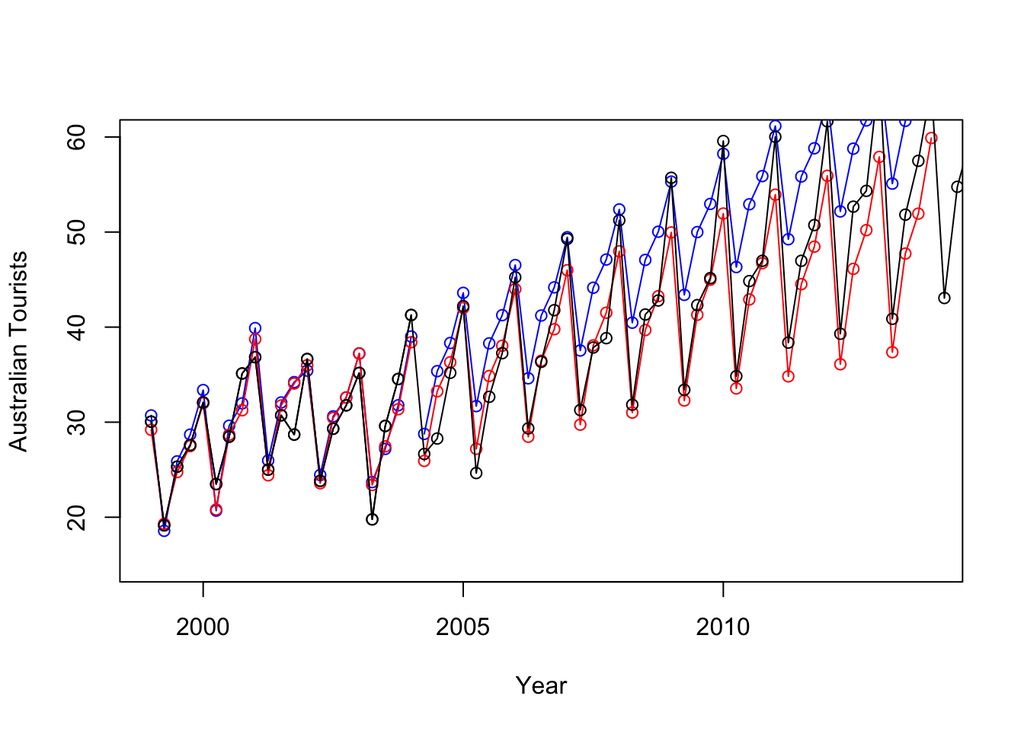

```r
# add the actual values to visually compare the forecasts to the actual values.
points(austourists, type = "o")
```

## Activity 4: Full Analysis

### Temperature Data

Using the `maxtemp` dataset granted by loading the `fpp2` package, there are maximum annual temperature data in Celsius. For more information, use `help(maxtemp)`. To see what you’re looking at, execute the command in ‘Examples’ in the help document.

We are only concerned with information after 1990. Please eliminate unwanted information or subset information we don’t care about.

Utilize SES to predict the next five years of maximum temperatures in Melbourne. Plot this information, including the prior information and the forecast. Add the predicted value line across 1990-present as a separate line, preferably blue. So, to review, you should have your fit, the predicted value line overlaying it, and a forecast through 2021, all on one axis. Find the AICc and BIC of this fitted model. You will use that information later.

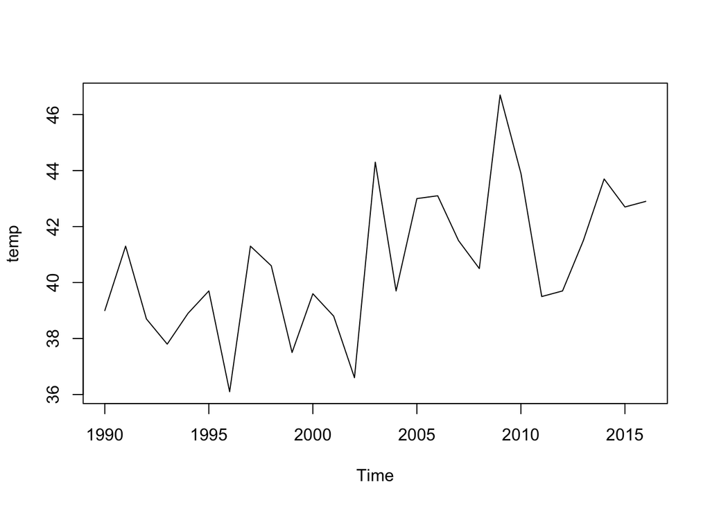

```r
# Create time series
temp <- window(maxtemp, start = 1990, end = 2016)

# Plot the data
plot(temp)
```

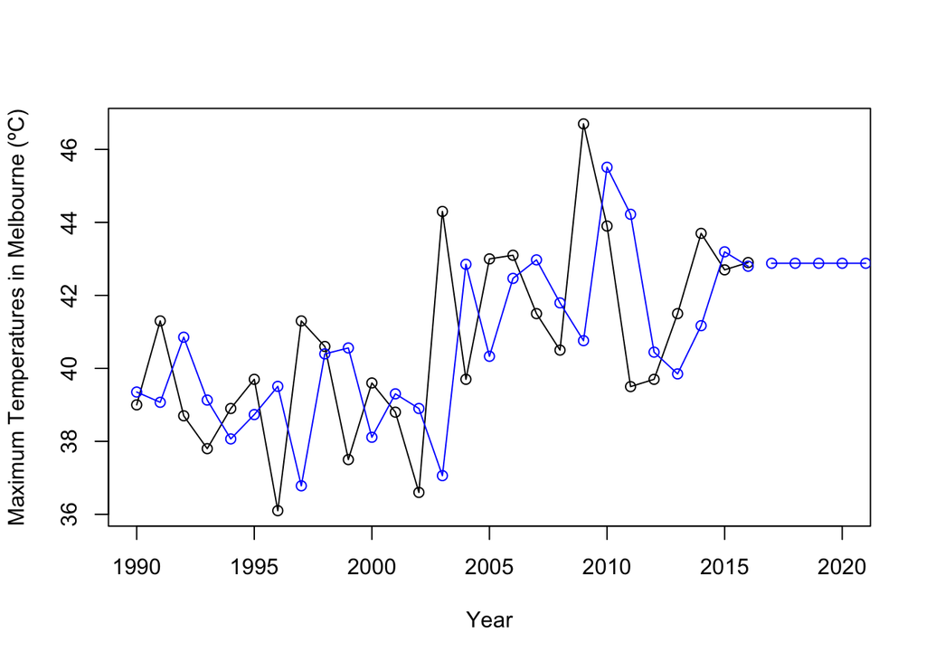

```r
# Predict next 5 years
fit1 <- ses(temp, initial = "optimal", alpha = .8, h = 5)

# Plot the original data & the predictions
plot(temp, ylab = "Maximum Temperatures in Melbourne (ºC)", xlab = "Year", type = "o", xlim = c(1990, 2020))

# Plot the estimated values from the model
lines(fitted(fit1), col = "blue", type = "o")

# Plot the forecast
lines(fit1$mean, col = "blue", type = "o")
```

```r
# Compare the forecasts with the actual values with various fit metrics.
# accuracy(fit1, temp)
```

Now use a damped Holt’s linear trend to also predict out five years. Make sure `initial = “optimal”`. As above, create a similar plot to 1C, but use the Holt fit instead.

```r
# Holt's linear trend model for temp
fit1h <- holt(temp, alpha = .8, beta = .2, initial = "simple", h = 5)
# fit2h <- holt(air, alpha = .8, beta = .2, initial = "simple", exponential = TRUE, h = 5)

# Check out estiamted values of the "training" data from the first holt model
fitted(fit1h)
```

```
## Time Series:
## Start = 1990
## End = 2016
## Frequency = 1
##  [1] 41.30000 41.39200 43.23568 40.79871 39.11152 39.62024 40.37474 36.96169
##  [9] 41.13321 41.32220 38.26844 39.55074 39.04708 36.79482 43.70519 40.76644
## [17] 43.17606 43.72581 42.19963 40.82246 46.44743 44.92483 40.23234 39.36867
## [25] 40.97695 43.49429 43.07067
```

```r
# Check out the forecast value (h of them)
fit1h$mean
```

```
## Time Series:
## Start = 2017
## End = 2021
## Frequency = 1
## [1] 43.11864 43.30315 43.48766 43.67216 43.85667
```

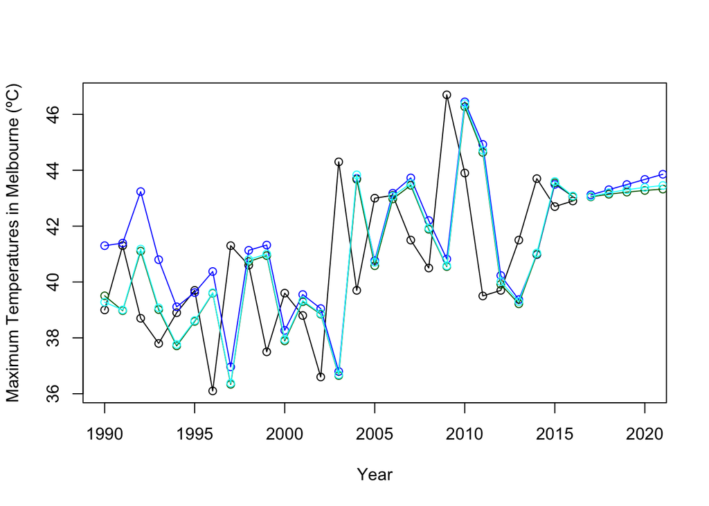

```r
# Plot the original data & the predictions
plot(temp, ylab = "Maximum Temperatures in Melbourne (ºC)", xlab = "Year", type = "o", xlim = c(1990, 2020))

# Plot estimated values of the training data
lines(fitted(fit1h), col = "blue", type = "o")

# Plot forecast
lines(fit1h$mean, col = "blue", type = "o")

# Fit another model ... damped!
fit3h <- holt(temp, alpha = .8, beta = .2, damped = TRUE, initial = "optimal", h = 5)

# Plot the fitted value (estimated from training data)
lines(fitted(fit3h), col = "darkgreen", type = "o")

# Plot the forecasts
lines(fit3h$mean, col = "darkgreen", type = "o")

# Fit another model ... what is the difference?
fit4h <- holt(temp, alpha = .8, beta = .2, damped = TRUE, initial = "optimal", exponential = TRUE, h = 5)

# Plot the fitted value (estimated from triaining data)
lines(fitted(fit4h), col = "cyan", type = "o")

# Plot the forecasts
lines(fit4h$mean, col = "cyan", type = "o")
```

```r
# with implicit Test set... it figures out by the time which are training and which are test.
# accuracy(fit1h, temp)
```

## Bonus: The Wands Choose the Wizards

We will cover this in Live Session… get a head start if you have time!

- Utilize the dygraphs library. Read in both Unit12TimeSeries_Ollivander and _Gregorovitch.csv as two different data frames. They do not have headers, so make sure you account for that. This is a time series of Wands sold over years.
- You don’t have your information in the proper format! In both data sets, you’ll need to first convert the date-like variable to an actual Date class.
- Use the library xts (and the xts() function in it) to make each data frame an xts object (effectively, a time series). You’ll want to order.by the Date variable.
- Bind the two xts objects together and create a dygraph from it. Utilize the help() index if you’re stuck.
- Give an effective title and x/y axes.
- Label each Series (via dySeries) to be the appropriate wand-maker. So, one line should create a label for Ollivander and the other for Gregorovitch.
- Stack this graph and modify the two lines to be different colors (and not the default ones!) Any colors are fine, but make sure they’re visible and that Ollivander is a different color than Gregorovitch.
- Activate a range selector and make it big enough to view.
- Use dyShading to illuminate approximately when Voldemort was revived and at-large: between 1995 to 1999.
- Enable Highlighting on the graph, so mousing over a line bolds it.

```r
library(dygraphs)
library(xts)
# Import the data
ollivander <- read_csv(here::here("6306", "week 11", "Unit11TimeSeries_Ollivander.csv"),
    col_names = FALSE, col_types = cols(X1 = col_date(format = "%m/%d/%Y")))
gregorovitch <- read_csv(here::here("6306", "week 11", "Unit11TimeSeries_Gregorovitch.csv"),
    col_names = FALSE, col_types = cols(X1 = col_date(format = "%m/%d/%Y")))

# Set names
ollivander <- ollivander %>%
  rename(date = X1,
         wands = X2) %>%
  mutate(wandmaker = "Ollivander")
gregorovitch <- gregorovitch %>%
  rename(date = X1,
         wands = X2) %>%
  mutate(wandmaker = "Gregorovitch")

# Make time series
ollivander_ts <- xts(ollivander, order.by = ollivander$date)
gregorovitch_ts <- xts(gregorovitch, order.by = gregorovitch$date)

# Bind data together
wands <- cbind(ollivander_ts, gregorovitch_ts)

# Make dygraph
dygraph(wands,
        main = "Wands Sold by Wandmaker",
        xlab = "Date",
        ylab = "Wands Sold",) %>%
  dySeries("wands", label = "Ollivander") %>%
  dySeries("wands.1", label = "Gregorovitch") %>%
  dyRangeSelector(height = 20) %>%
  dyOptions(colors = RColorBrewer::brewer.pal(3, "Set1")) %>%
  dyShading(from = "1995-01-01", to = "1999-12-31") %>%
  dyHighlight()
```

[interactive chart not shown]